# Suicidal ideation and adolescent friendship networks — Supplement

October 30, 2026

# Overview

This report covers wave 1 directed ERGMs and directed STERGMs (wave 1 → wave 2), each fit separately to every community. **By Community** shows each community’s own results; **Paper Figures** summarizes every community’s estimates; the numbered sections that follow describe the networks and pool the estimates across communities. Models are defined in `config/ergm_model_desc.csv` and `config/stergm_model_desc.csv`; only rows with `show_in_report = TRUE` appear. All results are read from aggregate CSV files in **reference_results**, so no individual-level data is needed to build this report.

| Metric | Value |
| --- | --- |
| Communities | 16 |
| Respondents (wave 1 nodes) | 3,702 |
| Wave 1 arcs (directed nominations) | 9,370 |
| Median community size | 87 |
| Small communities (n < 50) | 3 |
| High-attrition communities (> 30%) | 3 |

Models in this report

Type

Model

Description

Results

Integrated

ERGM (wave 1)

m14a

edges + ideation (homophily, in/out cov)

current (2026-10-21 12:07:00)

—

ERGM (wave 1)

m14c

- homophily (clubs, gender, grade)

current (2026-10-21 12:07:00)

—

ERGM (wave 1)

m14d

- mental health covariates (cesd, social support)

current (2026-10-21 12:07:00)

—

STERGM (both)

m7 step 1

edges + ideation (homophily, nodei/ocov)

current (2026-10-21 17:12:00)

—

STERGM (both)

m7 step 2

- mutual + edgecov(shared clubs) + nodematch(gender)

current (2026-10-21 17:12:00)

—

STERGM (both)

m7 step 3

- nodei/ocov(cesd, social support)

current (2026-10-21 17:12:00)

—

STERGM (both)

m7 step 3

- nodei/ocov(cesd squared)

current (2026-10-21 17:12:00)

—

**How pooled results are made (both model types).** Each model is fit separately to every community large enough to fit (default n ≥ 15 for ERGMs, n ≥ 20 for STERGMs), using stochastic approximation (Snijders 2002). Fits that fail or do not converge are excluded. So are degenerate fits: any |estimate| > 10 or SE > 10 excludes the whole ERGM or STERGM sub-model. Terms whose attribute has no usable variation in a community (e.g. no ideation cases) are dropped for that community only. For each term, the usable per-community estimates are then combined in a random-effects meta-analysis (REML, `metafor`). Each estimate is treated as the community’s true value plus estimation error: precise estimates get more weight, and real between-community differences (τ²) are separated from noise. **Small communities (n < 50) are excluded from the primary pooled estimates** and used as a sensitivity check. Based on Snijders & Baerveldt (2003), An (2015) and Tolochko & Boomgaarden (2024).

# By Community

Choose a community to see its network, its ERGM and STERGM estimates side by side, and the fit diagnostics for each model. Featured communities (`FEATURED_COMMUNITIES`) are listed first. Cells show the log-odds estimate with stars (`+` p<.1, `*` p<.05, `**` p<.01, `***` p<.001) and the SE below it in parentheses. `†` = SE not estimable. `n/c` = the fit failed, did not converge or was degenerate (hover for the reason). `—` = the term is not in that model, or was dropped for this community. Dissolution tables are tergm ≥ 4 **persistence** estimates: > 0 = an arc is more likely to persist. The checkboxes in the bar choose which models are shown.

**§** in the network and sample tables = too few cases to report. A community’s figures for a measure are withheld when they rest on fewer than 10 people, when any category has 1 to 9 people, or when everyone falls in one category (so a prevalence of 0% or 100% is also withheld).

**Community:**

**ERGMs:** m14a m14c m14d

**STERGMs:** m7 step 1 m7 step 2 m7 step 3 m7 step 3

### Community 406 (n = 83)

#### Network

| Wave | Nodes | Arcs | Density | Avg degree | Reciprocity | Clustering | Components | Isolates | Largest component |
| --- | --- | --- | --- | --- | --- | --- | --- | --- | --- |
| 1 | 83 | 159 | 0.023 | 3.83 | 0.277 | 0.225 | 15 | 14 | 69 |
| 2 | 83 | 129 | 0.019 | 3.11 | 0.264 | 0.217 | 22 | 21 | 62 |

Between waves: 81 arcs formed, 111 dissolved (people present at both waves).

#### Degree distribution (wave 2: people observed at wave 2)

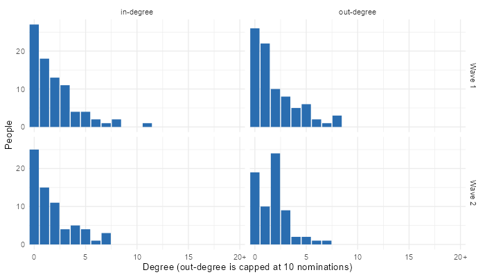

#### Sample

| Measure | Wave 1 | Wave 2 |
| --- | --- | --- |
| **Demographics** |  |  |
| Female | 53.0% |  |
| Age, mean (SD) | 12.82 (0.86) |  |
| Grade composition | § |  |
| Race/ethnicity (Hispanic first) | § |  |
| Race/ethnicity heterogeneity (0-1) | 0.05 |  |
| **SES** |  |  |
| Parental education, mean (1-9) | 7.20 (1.98) |  |
| Parent on welfare | § |  |
| **Suicide-related** |  |  |
| Suicidal ideation | 14.6% | 16.2% |
| Ideation onset (W1 non-ideators) |  | § |
| Ideation remission (W1 ideators) |  | § |
| Suicide attempt | § | § |
| Any suicide exposure | § | 18.1% |
| Peer suicide death exposure | § | § |
| **Psychosocial** |  |  |
| CES-D, mean (SD) | 9.89 (6.91) | 11.31 (7.61) |
| Hopelessness, mean (0-3) | 0.84 | 0.85 |
| Loneliness, mean (0-3) | 0.48 | 0.56 |
| Social support, mean | 4.17 | 3.99 |
| Any substance use | 45.8% | 44.6% |
| **Data quality** |  |  |
| Lost to follow-up at wave 2 |  | 18.1% |
| CES-D missing | § |  |
| Social support missing | § |  |
| Race/ethnicity missing | § |  |
| Grade missing | § |  |
| No in-school club data | 12.0% |  |
| In at least one club (with club data) | § |  |
| Clubs per student, mean | 3.22 |  |

#### Wave 1 ERGMs

| Term | m14a | m14c | m14d |
| --- | --- | --- | --- |
| Edges | -3.433*** (0.391) | -4.125*** (0.856) | -5.355*** (1.229) |
| Ideation status homophily | -0.328 (0.391) | 0.190 (0.604) | 0.003 (0.680) |
| Ideation: receiver | -0.348 (0.391) | 0.123 (0.604) | 0.188 (0.686) |
| Ideation: sender | -0.066 (0.391) | 0.416 (0.615) | 0.246 (0.675) |
| Reciprocity | — | 1.892*** (0.369) | 2.078*** (0.361) |
| GW in-degree (decay=0.5) | — | -1.189* (0.479) | -1.614*** (0.431) |
| GW out-degree (decay=0.5) | — | -0.941+ (0.569) | -1.110* (0.431) |
| GW shared partners, OSP (decay=0.25) | — | 0.638* (0.273) | 0.377 (0.280) |
| GW shared partners, ISP (decay=0.25) | — | -0.255 (0.297) | -0.091 (0.281) |
| GW dyadwise shared partners, OSP (decay=0.25) | — | -0.003 (0.036) | 0.009 (0.018) |
| GW dyadwise shared partners, ISP (decay=0.25) | — | 0.028 (0.050) | 0.016 (0.026) |
| Shared club membership | — | 0.343* (0.142) | 0.268+ (0.160) |
| Same gender | — | 0.440** (0.140) | 0.400* (0.177) |
| Same grade | — | 0.688+ (0.404) | 0.866* (0.395) |
| Depressive symptoms: receiver | — | — | -0.008 (0.015) |
| Depressive symptoms: sender | — | — | 0.002 (0.016) |
| Social support: receiver | — | — | 0.137 (0.162) |
| Social support: sender | — | — | 0.260 (0.160) |
| Status | fit (SA) | fit (SA) | fit (SA) |
| AIC | 1.52e+03 | 1.63e+03 | 1.88e+03 |
| BIC | 1.54e+03 | 1.72e+03 | 2.00e+03 |

#### STERGM formation (wave 1 → 2)

| Term | m7 step 1 | m7 step 2 | m7 step 3 | m7 step 3 |
| --- | --- | --- | --- | --- |
| Edges | -4.412*** (0.419) | -4.981† | -6.237† | -6.495† |
| Ideation status homophily | -0.039 (0.419) | -0.115† | -0.111† | -0.132† |
| Ideation: receiver | 0.187 (0.419) | 0.085† | 0.112† | 0.044† |
| Ideation: sender | 0.106 (0.419) | 0.009† | 0.042† | 0.020† |
| Reciprocity | — | 2.489† | 2.464† | 2.533† |
| Shared club membership | — | 0.138† | 0.180† | 0.140† |
| Same gender | — | 0.608† | 0.618† | 0.608† |
| Depressive symptoms: receiver | — | — | 0.015† | 0.073† |
| Depressive symptoms: sender | — | — | 0.010† | 0.012† |
| Social support: receiver | — | — | 0.186† | 0.193† |
| Social support: sender | — | — | 0.049† | 0.047† |
| Depressive symptoms squared: receiver | — | — | — | -0.002† |
| Depressive symptoms squared: sender | — | — | — | -0.000† |
| Status | fit (SA) | fit (SA) | fit (SA) | fit (SA) |

#### STERGM dissolution, as persistence (> 0 = arc more likely to persist)

| Term | m7 step 1 | m7 step 2 | m7 step 3 | m7 step 3 |
| --- | --- | --- | --- | --- |
| Edges | -1.513+ (0.799) | n/c | -6.057† | -6.120† |
| Ideation status homophily | 0.753 (0.799) | n/c | 3.559† | 3.246† |
| Ideation: receiver | 0.191 (0.799) | n/c | 2.326† | 2.025† |
| Ideation: sender | 0.569 (0.799) | n/c | 3.510† | 3.231† |
| Reciprocity | — | n/c | 2.515† | 2.455† |
| Shared club membership | — | n/c | -0.269† | -0.228† |
| Same gender | — | n/c | 0.236† | 0.295† |
| Depressive symptoms: receiver | — | — | 0.026† | 0.024† |
| Depressive symptoms: sender | — | — | 0.038† | 0.038† |
| Social support: receiver | — | — | -0.241† | -0.169† |
| Social support: sender | — | — | 0.408† | 0.416† |
| Status | fit (SA) | degenerate (SA) | fit (SA) | fit (SA) |

#### Fit notes

| Model | Sub-model | Status | Notes |
| --- | --- | --- | --- |
| m14a |  | fit (SA) | **Imputed:** ideation_binary_w1: 1 (zero) **Collinear (\|r\| ≥ 0.7):** Edges & Ideation status homophily (r = -0.97); Edges & Ideation: receiver (r = -0.82); Ideation status homophily & Ideation: rece… |
| m14c |  | fit (SA) | **Imputed:** ideation_binary_w1: 1 (zero); grade_w1: 2 (mean); shared_club: 10/83 vertices missing club data **Collinear (\|r\| ≥ 0.7):** Edges & Ideation status homophily (r = -0.70); Ideation status… |
| m14d |  | fit (SA) | **Imputed:** ideation_binary_w1: 1 (zero); grade_w1: 2 (mean); social_support_w1: 3 (mean); shared_club: 10/83 vertices missing club data **Collinear (\|r\| ≥ 0.7):** Ideation status homophily & Ideat… |
| m7 step 1 | dissolution | fit (SA) | **Imputed:** ideation_binary_w1: 1 (zero) **Collinear (\|r\| ≥ 0.7):** Edges & Ideation status homophily (r = -0.97); Edges & Ideation: receiver (r = -0.75); Ideation status homophily & Ideation: rece… |
| m7 step 1 | formation | fit (SA) | **Imputed:** ideation_binary_w1: 1 (zero) **Collinear (\|r\| ≥ 0.7):** Edges & Ideation status homophily (r = -0.95); Edges & Ideation: receiver (r = -0.76); Ideation status homophily & Ideation: rece… |
| m7 step 2 | dissolution | degenerate (SA) | **Imputed:** ideation_binary_w1: 1 (zero); shared_club: 10/83 vertices missing club data **Poor GOF (p < 0.05):** odeg, ideg, espart **Warnings:** 'tergm::stergm' is deprecated. See help("Deprecated")… |
| m7 step 2 | formation | fit (SA) | **Imputed:** ideation_binary_w1: 1 (zero); shared_club: 10/83 vertices missing club data **Poor GOF (p < 0.05):** odeg, ideg, espart **Warnings:** 'tergm::stergm' is deprecated. See help("Deprecated")… |
| m7 step 3 | dissolution | fit (SA) | **Imputed:** ideation_binary_w1: 1 (zero); social_support_w1: 3 (mean); shared_club: 10/83 vertices missing club data **Poor GOF (p < 0.05):** odeg, ideg, espart **Warnings:** 'tergm::stergm' is depre… |
| m7 step 3 | formation | fit (SA) | **Imputed:** ideation_binary_w1: 1 (zero); social_support_w1: 3 (mean); shared_club: 10/83 vertices missing club data **Poor GOF (p < 0.05):** odeg, ideg, espart **Warnings:** 'tergm::stergm' is depre… |
| m7 step 3 | dissolution | fit (SA) | **Imputed:** ideation_binary_w1: 1 (zero); social_support_w1: 3 (mean); shared_club: 10/83 vertices missing club data **Poor GOF (p < 0.05):** odeg, ideg, espart **Warnings:** 'tergm::stergm' is depre… |
| m7 step 3 | formation | fit (SA) | **Imputed:** ideation_binary_w1: 1 (zero); social_support_w1: 3 (mean); shared_club: 10/83 vertices missing club data **Poor GOF (p < 0.05):** odeg, ideg, espart **Warnings:** 'tergm::stergm' is depre… |

#### Goodness of fit

**GOF: m14d**

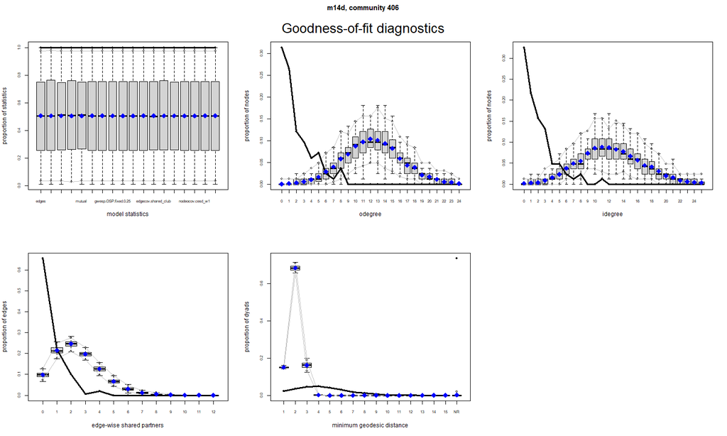

**GOF: m7 step 3**

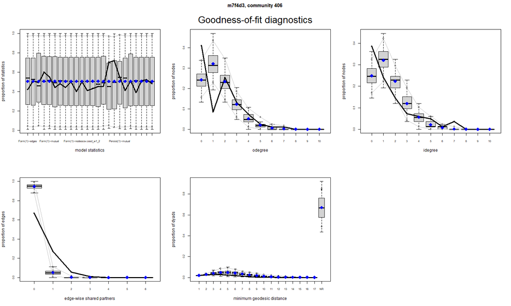

# Paper Tables

Paper tables place the selected model sequence side by side for each community, separately for ERGMs, formation, and persistence. Each usable estimate is accompanied by its 95% Wald confidence interval and significance stars. In each config CSV, `paper_name` selects a model and supplies its column heading. CSV row order determines column order.

RTF files open as editable tables in Word; HTML files can be viewed or printed separately, and CSV files contain the same formatted cells. Community labels and output settings are controlled by `PAPER_TABLE_COMMUNITIES` and `PAPER_TABLE_DIR` above. Unusable estimates are marked **n/e**, never presented as null results. Exporting only reads aggregate CSVs and does not refit models. The same exports can be made without knitting by running `paper_tables.R`.

Files saved in **outputs/tables_paper**.

| Type | Component | Community | Format | File |
| --- | --- | --- | --- | --- |
| ergm | ergm | A | html | outputs/tables_paper/ergm_ergm_community_406.html |
| ergm | ergm | A | rtf | outputs/tables_paper/ergm_ergm_community_406.rtf |
| ergm | ergm | A | csv | outputs/tables_paper/ergm_ergm_community_406.csv |
| ergm | ergm | B | html | outputs/tables_paper/ergm_ergm_community_408.html |
| ergm | ergm | B | rtf | outputs/tables_paper/ergm_ergm_community_408.rtf |
| ergm | ergm | B | csv | outputs/tables_paper/ergm_ergm_community_408.csv |
| ergm | ergm | C | html | outputs/tables_paper/ergm_ergm_community_428.html |
| ergm | ergm | C | rtf | outputs/tables_paper/ergm_ergm_community_428.rtf |
| ergm | ergm | C | csv | outputs/tables_paper/ergm_ergm_community_428.csv |
| ergm | ergm | D | html | outputs/tables_paper/ergm_ergm_community_477.html |
| ergm | ergm | D | rtf | outputs/tables_paper/ergm_ergm_community_477.rtf |
| ergm | ergm | D | csv | outputs/tables_paper/ergm_ergm_community_477.csv |
| stergm | formation | A | html | outputs/tables_paper/stergm_formation_community_406.html |
| stergm | formation | A | rtf | outputs/tables_paper/stergm_formation_community_406.rtf |
| stergm | formation | A | csv | outputs/tables_paper/stergm_formation_community_406.csv |
| stergm | formation | B | html | outputs/tables_paper/stergm_formation_community_408.html |
| stergm | formation | B | rtf | outputs/tables_paper/stergm_formation_community_408.rtf |
| stergm | formation | B | csv | outputs/tables_paper/stergm_formation_community_408.csv |
| stergm | formation | C | html | outputs/tables_paper/stergm_formation_community_428.html |
| stergm | formation | C | rtf | outputs/tables_paper/stergm_formation_community_428.rtf |
| stergm | formation | C | csv | outputs/tables_paper/stergm_formation_community_428.csv |
| stergm | formation | D | html | outputs/tables_paper/stergm_formation_community_477.html |
| stergm | formation | D | rtf | outputs/tables_paper/stergm_formation_community_477.rtf |
| stergm | formation | D | csv | outputs/tables_paper/stergm_formation_community_477.csv |
| stergm | dissolution | A | html | outputs/tables_paper/stergm_dissolution_community_406.html |
| stergm | dissolution | A | rtf | outputs/tables_paper/stergm_dissolution_community_406.rtf |
| stergm | dissolution | A | csv | outputs/tables_paper/stergm_dissolution_community_406.csv |
| stergm | dissolution | B | html | outputs/tables_paper/stergm_dissolution_community_408.html |
| stergm | dissolution | B | rtf | outputs/tables_paper/stergm_dissolution_community_408.rtf |
| stergm | dissolution | B | csv | outputs/tables_paper/stergm_dissolution_community_408.csv |
| stergm | dissolution | C | html | outputs/tables_paper/stergm_dissolution_community_428.html |
| stergm | dissolution | C | rtf | outputs/tables_paper/stergm_dissolution_community_428.rtf |
| stergm | dissolution | C | csv | outputs/tables_paper/stergm_dissolution_community_428.csv |
| stergm | dissolution | D | html | outputs/tables_paper/stergm_dissolution_community_477.html |
| stergm | dissolution | D | rtf | outputs/tables_paper/stergm_dissolution_community_477.rtf |
| stergm | dissolution | D | csv | outputs/tables_paper/stergm_dissolution_community_477.csv |

# Paper Figures

One figure per entry in `PAPER_FIGURES`, in up to two sets (`PAPER_FIG_ORDERS`). Each panel is one term, and each row is one community with its 95% confidence interval. In the first set, each panel’s rows are sorted by that term’s estimate, so rows do not line up across panels. In the second set, rows are sorted by community ID and are the same in every panel, so a community can be followed across terms (an empty row means that term is missing or unusable for that community). **Filled blue** points have a 95% CI that excludes 0 (p < .05); **open grey** points do not. Featured communities (`FEATURED_COMMUNITIES`, or a figure’s own `featured`) are ringed in orange and labelled. X axes differ by panel. Only usable fits are drawn: communities whose fit failed, did not converge or was degenerate, or whose term had no SE, are left out, and the caption gives the count. Each figure is split into parts of at most six panels, preserving term order, and every part is saved as a PDF and a 300-dpi PNG with `_part1`, `_part2`, etc. appended to its filename in the **outputs/figures_paper** folder next to this file.

## Rows sorted by estimate

### Wave 1 ERGM: m14d

**Part 1 of 3**

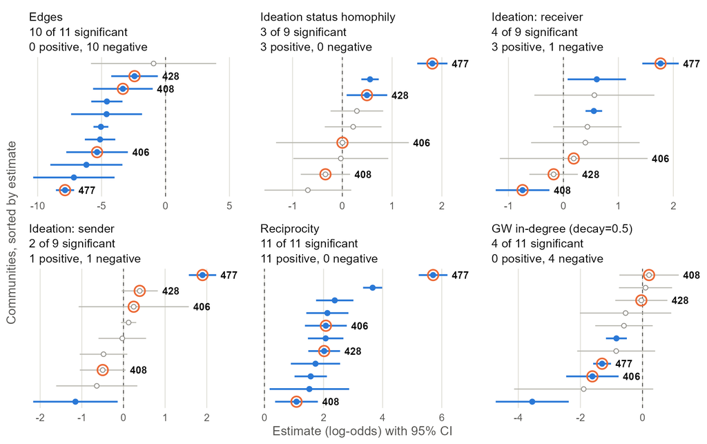

*11 communities shown in this part. Saved as `ergm_m14d_part1.pdf` / `ergm_m14d_part1.png`.*

**Part 2 of 3**

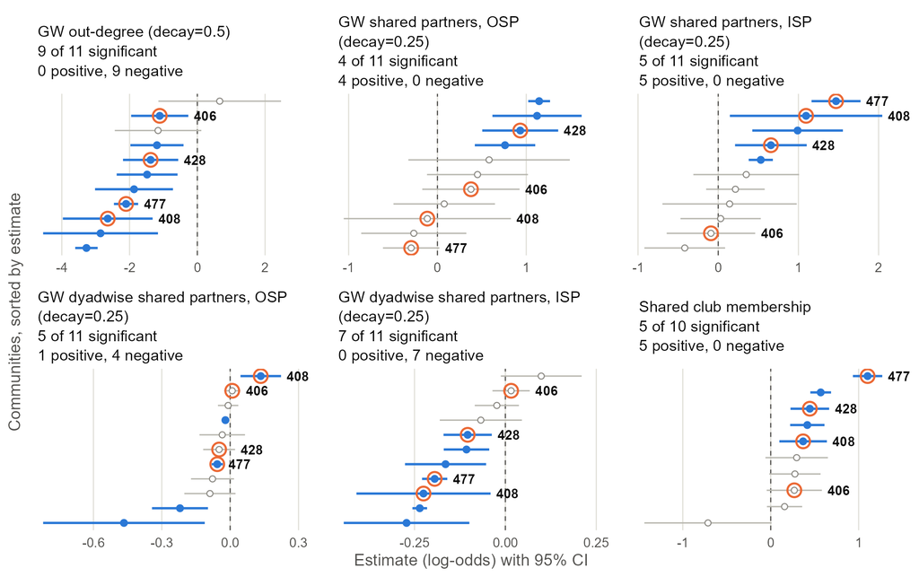

*11 communities shown in this part. Saved as `ergm_m14d_part2.pdf` / `ergm_m14d_part2.png`.*

**Part 3 of 3**

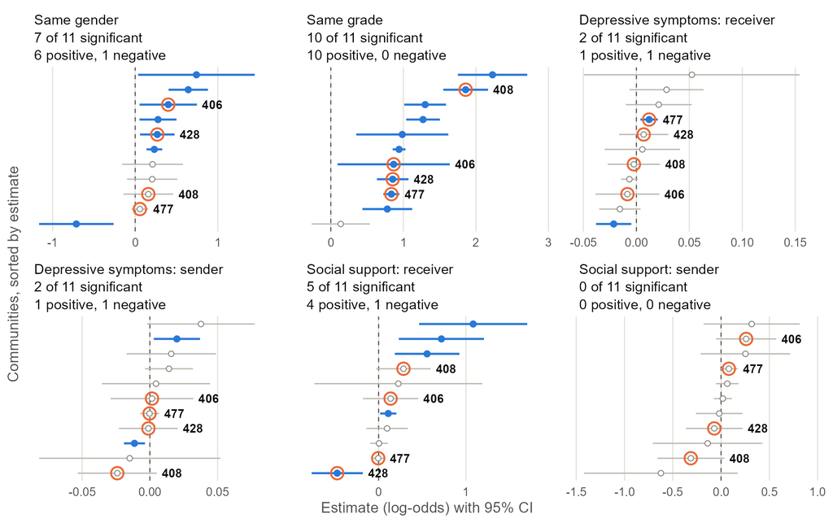

*11 communities shown in this part. Saved as `ergm_m14d_part3.pdf` / `ergm_m14d_part3.png`.*

*Across all parts: 11 communities shown of 16 fit (0 too small or too few tie changes).*

**Raw term names (to choose or order panels with `terms`)**

`edges`  
`nodematch.ideation_binary_w1`  
`nodeicov.ideation_binary_w1`  
`nodeocov.ideation_binary_w1`  
`mutual`  
`gwideg.fixed.0.5`  
`gwodeg.fixed.0.5`  
`gwesp.OSP.fixed.0.25`  
`gwesp.ISP.fixed.0.25`  
`gwdsp.OSP.fixed.0.25`  
`gwdsp.ISP.fixed.0.25`  
`edgecov.shared_club`  
`nodematch.gender`  
`nodematch.grade_w1`  
`nodeicov.cesd_w1`  
`nodeocov.cesd_w1`  
`nodeicov.social_support_w1`  
`nodeocov.social_support_w1`

### STERGM formation: m7 step 3

**Part 1 of 2**

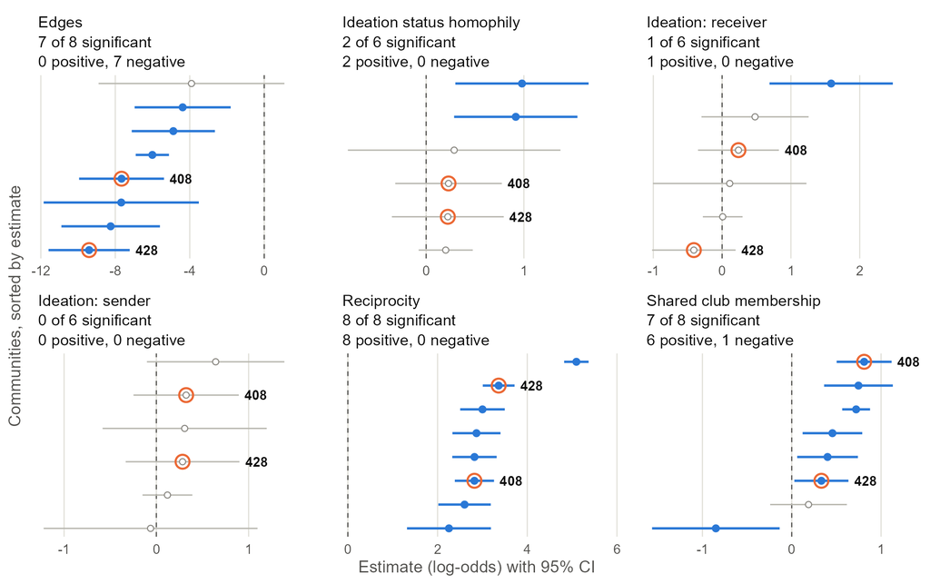

*8 communities shown in this part. Saved as `stergm_m7f3d3_formation_part1.pdf` / `stergm_m7f3d3_formation_part1.png`.*

**Part 2 of 2**

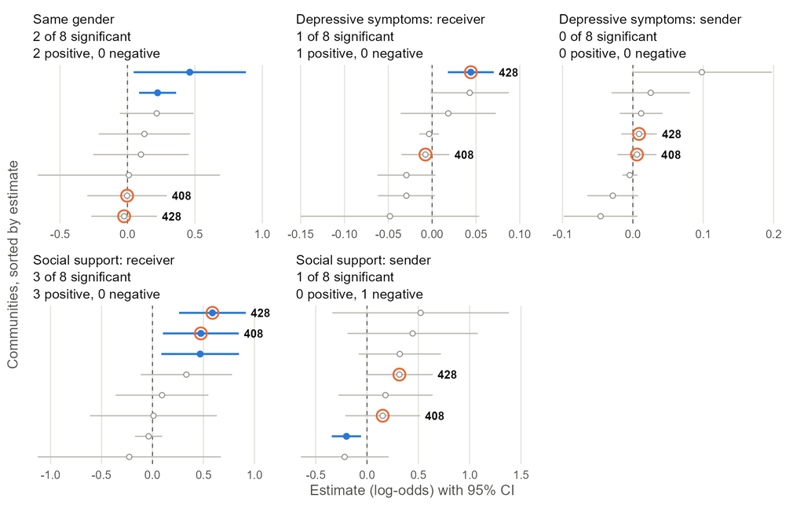

*8 communities shown in this part. Saved as `stergm_m7f3d3_formation_part2.pdf` / `stergm_m7f3d3_formation_part2.png`.*

*Across all parts: 8 communities shown of 15 fit (1 too small or too few tie changes).*

**Raw term names (to choose or order panels with `terms`)**

`Form(1)~edges`  
`Form(1)~nodematch.ideation_binary_w1`  
`Form(1)~nodeicov.ideation_binary_w1`  
`Form(1)~nodeocov.ideation_binary_w1`  
`Form(1)~mutual`  
`Form(1)~edgecov.shared_club`  
`Form(1)~nodematch.gender`  
`Form(1)~nodeicov.cesd_w1`  
`Form(1)~nodeocov.cesd_w1`  
`Form(1)~nodeicov.social_support_w1`  
`Form(1)~nodeocov.social_support_w1`

### STERGM persistence: m7 step 3

**Part 1 of 2**

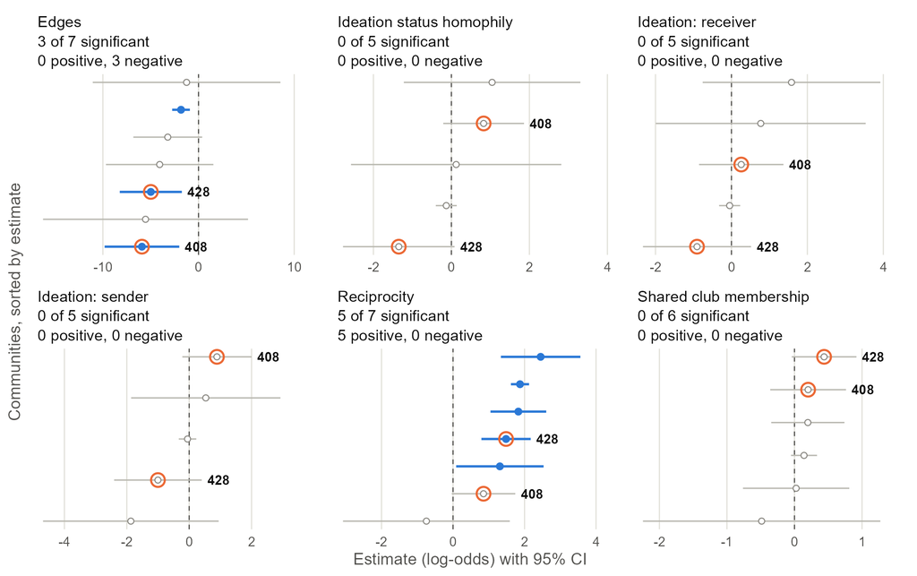

*7 communities shown in this part. Saved as `stergm_m7f3d3_dissolution_part1.pdf` / `stergm_m7f3d3_dissolution_part1.png`.*

**Part 2 of 2**

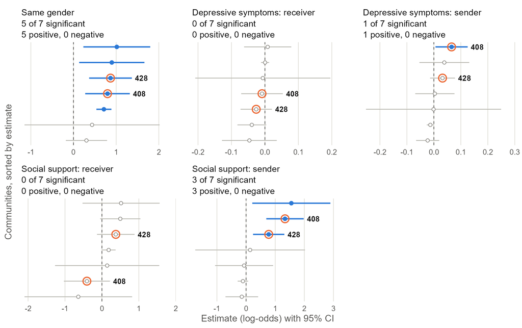

*7 communities shown in this part. Saved as `stergm_m7f3d3_dissolution_part2.pdf` / `stergm_m7f3d3_dissolution_part2.png`.*

*Across all parts: 7 communities shown of 15 fit (1 too small or too few tie changes).*

**Raw term names (to choose or order panels with `terms`)**

`Persist(1)~edges`  
`Persist(1)~nodematch.ideation_binary_w1`  
`Persist(1)~nodeicov.ideation_binary_w1`  
`Persist(1)~nodeocov.ideation_binary_w1`  
`Persist(1)~mutual`  
`Persist(1)~edgecov.shared_club`  
`Persist(1)~nodematch.gender`  
`Persist(1)~nodeicov.cesd_w1`  
`Persist(1)~nodeocov.cesd_w1`  
`Persist(1)~nodeicov.social_support_w1`  
`Persist(1)~nodeocov.social_support_w1`

### STERGM formation: m7 step 3

**Part 1 of 3**

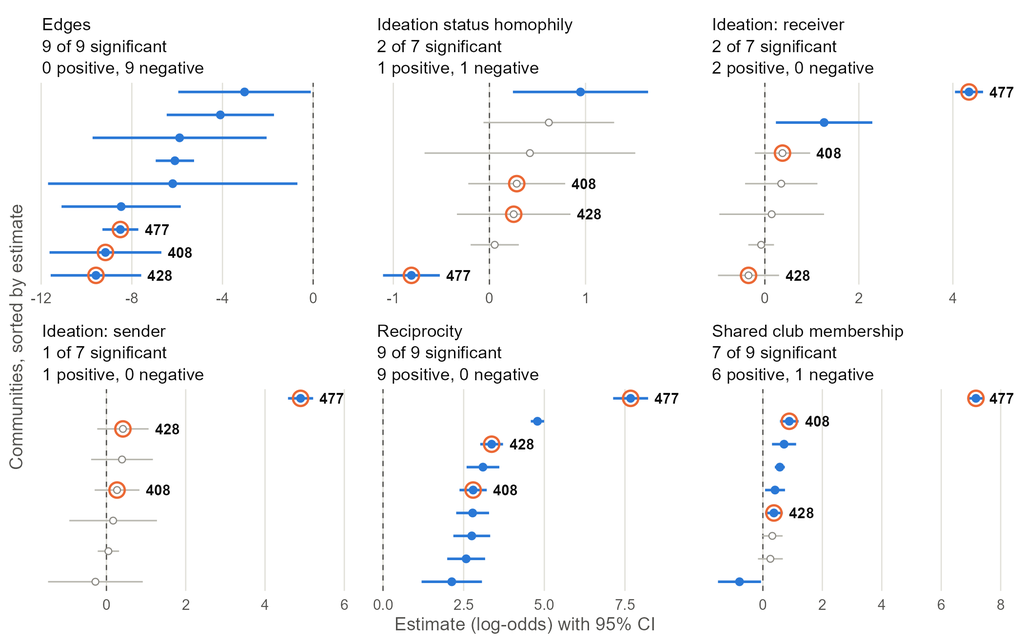

*9 communities shown in this part. Saved as `stergm_m7f4d3_formation_part1.pdf` / `stergm_m7f4d3_formation_part1.png`.*

**Part 2 of 3**

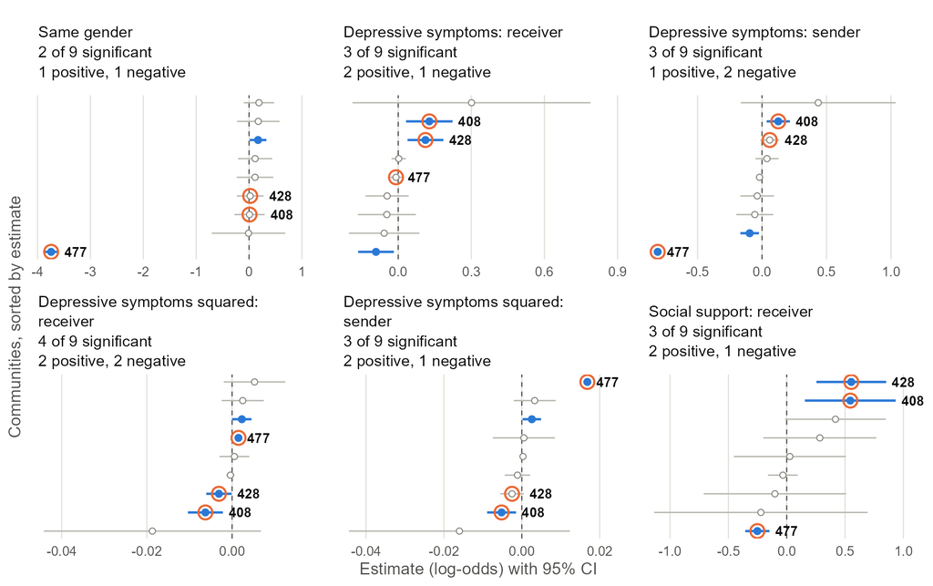

*9 communities shown in this part. Saved as `stergm_m7f4d3_formation_part2.pdf` / `stergm_m7f4d3_formation_part2.png`.*

**Part 3 of 3**

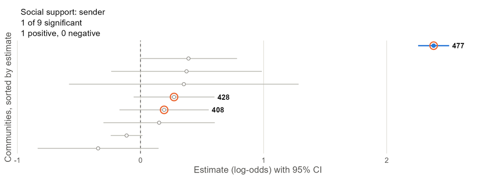

*9 communities shown in this part. Saved as `stergm_m7f4d3_formation_part3.pdf` / `stergm_m7f4d3_formation_part3.png`.*

*Across all parts: 9 communities shown of 15 fit (1 too small or too few tie changes).*

**Raw term names (to choose or order panels with `terms`)**

`Form(1)~edges`  
`Form(1)~nodematch.ideation_binary_w1`  
`Form(1)~nodeicov.ideation_binary_w1`  
`Form(1)~nodeocov.ideation_binary_w1`  
`Form(1)~mutual`  
`Form(1)~edgecov.shared_club`  
`Form(1)~nodematch.gender`  
`Form(1)~nodeicov.cesd_w1`  
`Form(1)~nodeocov.cesd_w1`  
`Form(1)~nodeicov.cesd_w1_2`  
`Form(1)~nodeocov.cesd_w1_2`  
`Form(1)~nodeicov.social_support_w1`  
`Form(1)~nodeocov.social_support_w1`

### STERGM persistence: m7 step 3

**Part 1 of 2**

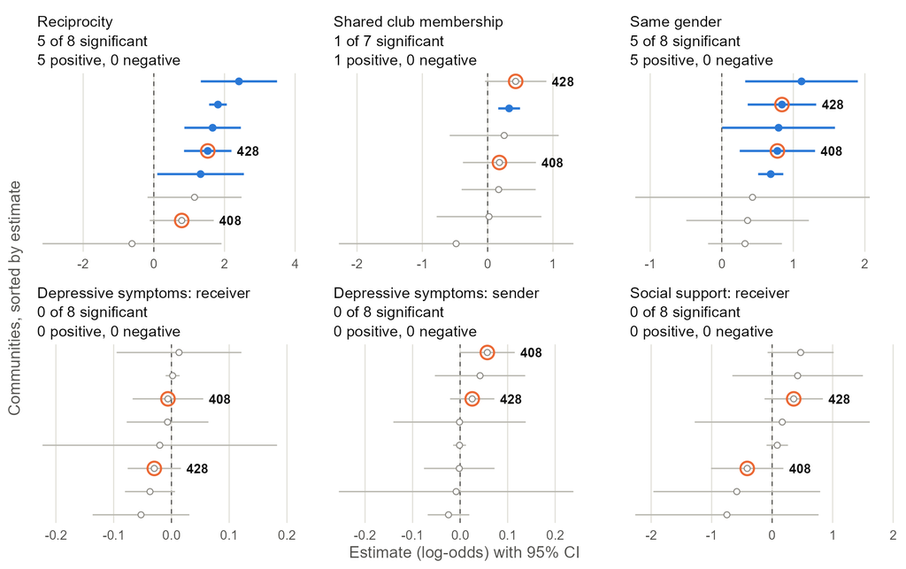

*8 communities shown in this part. Saved as `stergm_m7f4d3_dissolution_part1.pdf` / `stergm_m7f4d3_dissolution_part1.png`.*

**Part 2 of 2**

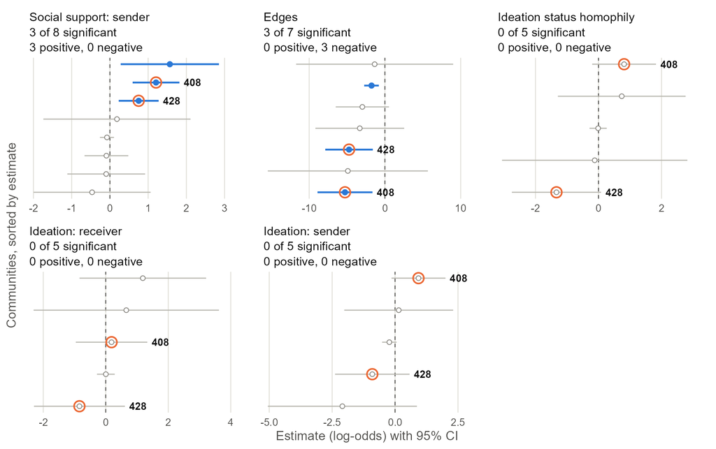

*8 communities shown in this part. Saved as `stergm_m7f4d3_dissolution_part2.pdf` / `stergm_m7f4d3_dissolution_part2.png`.*

*Across all parts: 8 communities shown of 15 fit (1 too small or too few tie changes).*

**Raw term names (to choose or order panels with `terms`)**

`Persist(1)~edges`  
`Persist(1)~nodematch.ideation_binary_w1`  
`Persist(1)~nodeicov.ideation_binary_w1`  
`Persist(1)~nodeocov.ideation_binary_w1`  
`Persist(1)~mutual`  
`Persist(1)~edgecov.shared_club`  
`Persist(1)~nodematch.gender`  
`Persist(1)~nodeicov.cesd_w1`  
`Persist(1)~nodeocov.cesd_w1`  
`Persist(1)~nodeicov.social_support_w1`  
`Persist(1)~nodeocov.social_support_w1`

## Rows sorted by community ID

### Wave 1 ERGM: m14d

**Part 1 of 3**

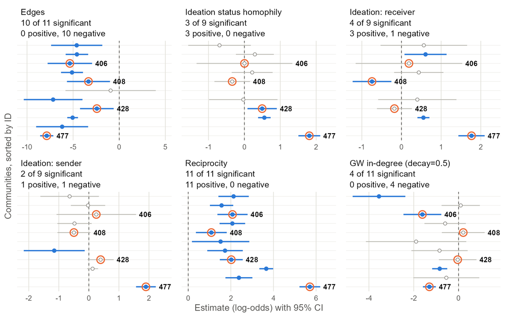

*11 communities shown in this part. Saved as `ergm_m14d_by_id_part1.pdf` / `ergm_m14d_by_id_part1.png`.*

**Part 2 of 3**

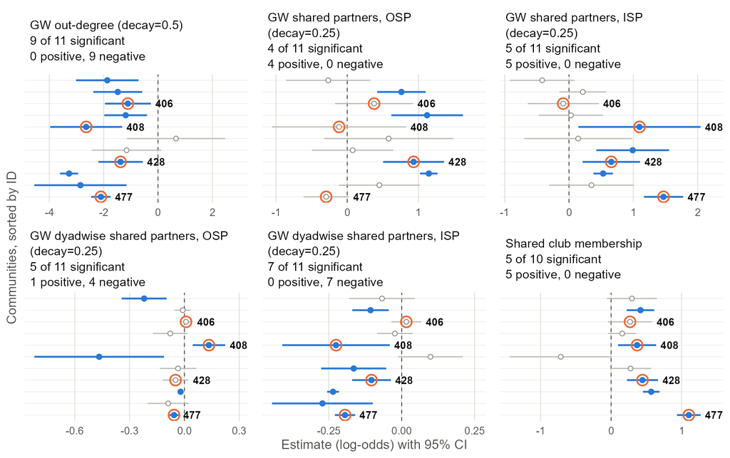

*11 communities shown in this part. Saved as `ergm_m14d_by_id_part2.pdf` / `ergm_m14d_by_id_part2.png`.*

**Part 3 of 3**

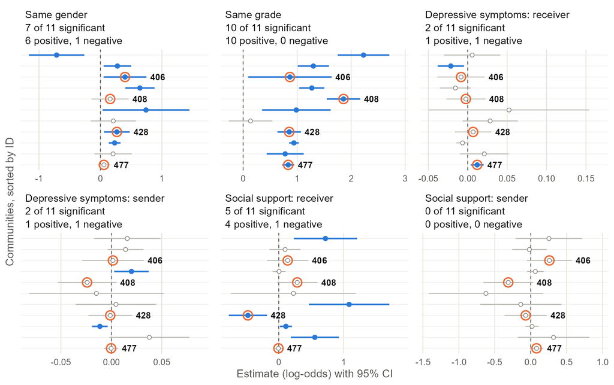

*11 communities shown in this part. Saved as `ergm_m14d_by_id_part3.pdf` / `ergm_m14d_by_id_part3.png`.*

*Across all parts: 11 communities shown of 16 fit (0 too small or too few tie changes).*

**Raw term names (to choose or order panels with `terms`)**

`edges`  
`nodematch.ideation_binary_w1`  
`nodeicov.ideation_binary_w1`  
`nodeocov.ideation_binary_w1`  
`mutual`  
`gwideg.fixed.0.5`  
`gwodeg.fixed.0.5`  
`gwesp.OSP.fixed.0.25`  
`gwesp.ISP.fixed.0.25`  
`gwdsp.OSP.fixed.0.25`  
`gwdsp.ISP.fixed.0.25`  
`edgecov.shared_club`  
`nodematch.gender`  
`nodematch.grade_w1`  
`nodeicov.cesd_w1`  
`nodeocov.cesd_w1`  
`nodeicov.social_support_w1`  
`nodeocov.social_support_w1`

### STERGM formation: m7 step 3

**Part 1 of 2**

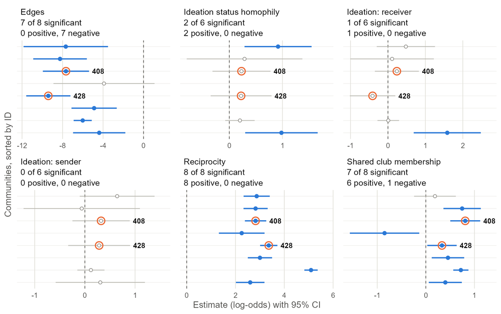

*8 communities shown in this part. Saved as `stergm_m7f3d3_formation_by_id_part1.pdf` / `stergm_m7f3d3_formation_by_id_part1.png`.*

**Part 2 of 2**

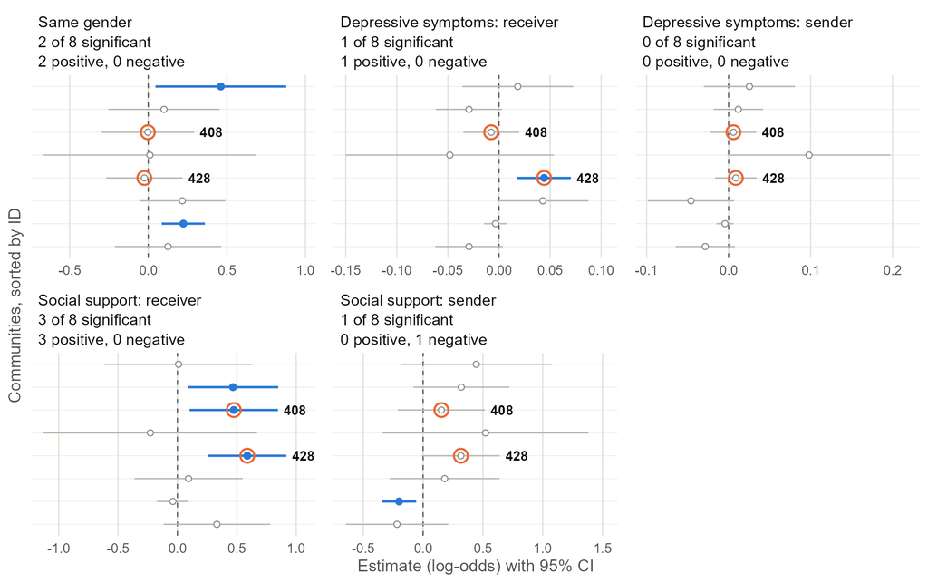

*8 communities shown in this part. Saved as `stergm_m7f3d3_formation_by_id_part2.pdf` / `stergm_m7f3d3_formation_by_id_part2.png`.*

*Across all parts: 8 communities shown of 15 fit (1 too small or too few tie changes).*

**Raw term names (to choose or order panels with `terms`)**

`Form(1)~edges`  
`Form(1)~nodematch.ideation_binary_w1`  
`Form(1)~nodeicov.ideation_binary_w1`  
`Form(1)~nodeocov.ideation_binary_w1`  
`Form(1)~mutual`  
`Form(1)~edgecov.shared_club`  
`Form(1)~nodematch.gender`  
`Form(1)~nodeicov.cesd_w1`  
`Form(1)~nodeocov.cesd_w1`  
`Form(1)~nodeicov.social_support_w1`  
`Form(1)~nodeocov.social_support_w1`

### STERGM persistence: m7 step 3

**Part 1 of 2**

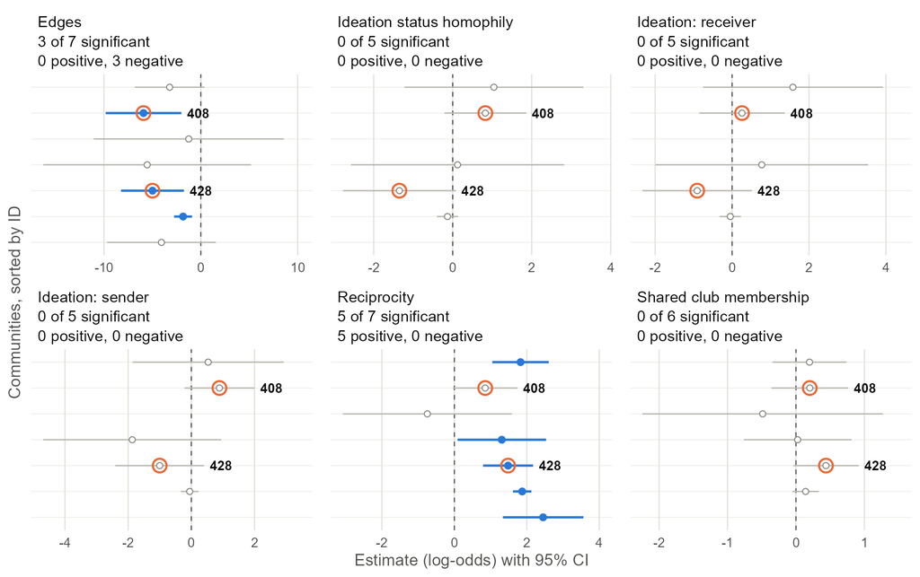

*7 communities shown in this part. Saved as `stergm_m7f3d3_dissolution_by_id_part1.pdf` / `stergm_m7f3d3_dissolution_by_id_part1.png`.*

**Part 2 of 2**

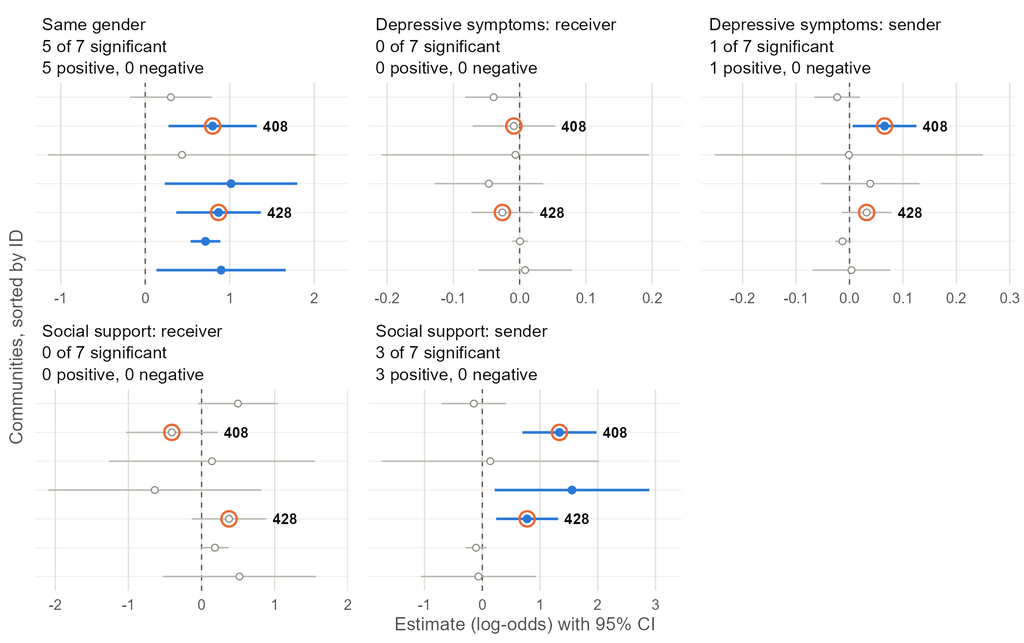

*7 communities shown in this part. Saved as `stergm_m7f3d3_dissolution_by_id_part2.pdf` / `stergm_m7f3d3_dissolution_by_id_part2.png`.*

*Across all parts: 7 communities shown of 15 fit (1 too small or too few tie changes).*

**Raw term names (to choose or order panels with `terms`)**

`Persist(1)~edges`  
`Persist(1)~nodematch.ideation_binary_w1`  
`Persist(1)~nodeicov.ideation_binary_w1`  
`Persist(1)~nodeocov.ideation_binary_w1`  
`Persist(1)~mutual`  
`Persist(1)~edgecov.shared_club`  
`Persist(1)~nodematch.gender`  
`Persist(1)~nodeicov.cesd_w1`  
`Persist(1)~nodeocov.cesd_w1`  
`Persist(1)~nodeicov.social_support_w1`  
`Persist(1)~nodeocov.social_support_w1`

### STERGM formation: m7 step 3

**Part 1 of 3**

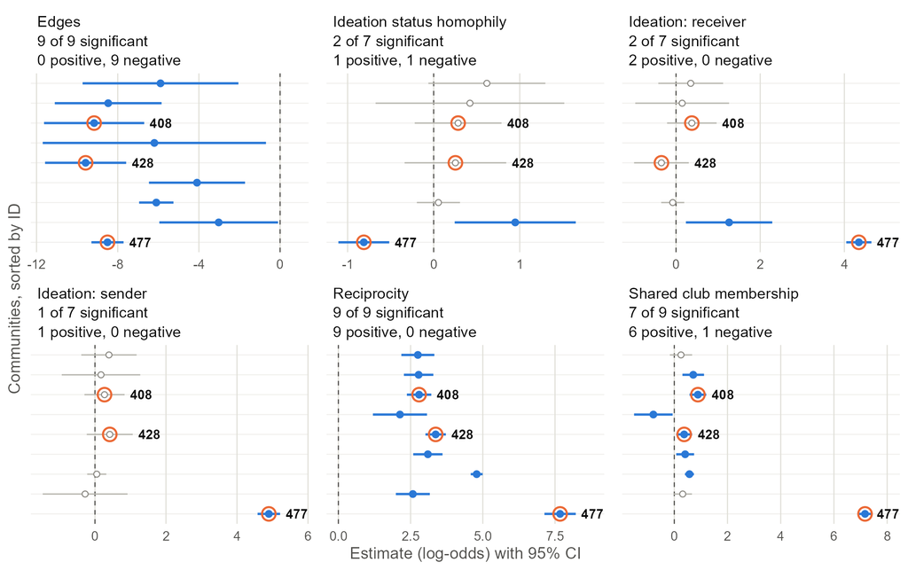

*9 communities shown in this part. Saved as `stergm_m7f4d3_formation_by_id_part1.pdf` / `stergm_m7f4d3_formation_by_id_part1.png`.*

**Part 2 of 3**

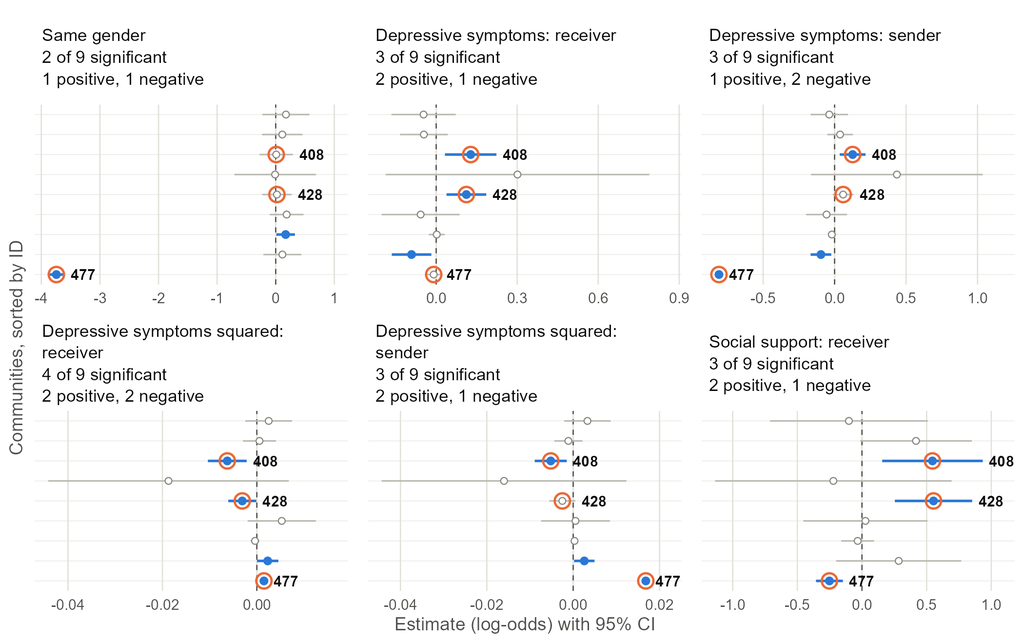

*9 communities shown in this part. Saved as `stergm_m7f4d3_formation_by_id_part2.pdf` / `stergm_m7f4d3_formation_by_id_part2.png`.*

**Part 3 of 3**

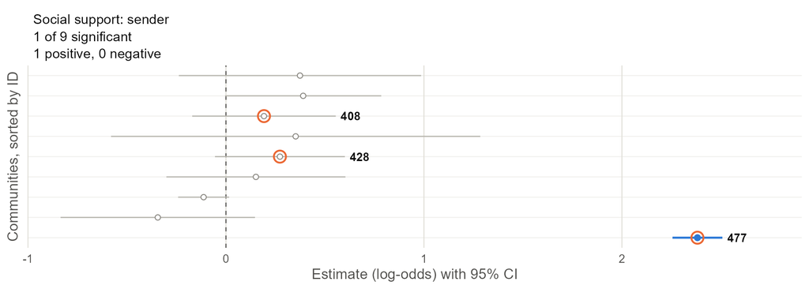

*9 communities shown in this part. Saved as `stergm_m7f4d3_formation_by_id_part3.pdf` / `stergm_m7f4d3_formation_by_id_part3.png`.*

*Across all parts: 9 communities shown of 15 fit (1 too small or too few tie changes).*

**Raw term names (to choose or order panels with `terms`)**

`Form(1)~edges`  
`Form(1)~nodematch.ideation_binary_w1`  
`Form(1)~nodeicov.ideation_binary_w1`  
`Form(1)~nodeocov.ideation_binary_w1`  
`Form(1)~mutual`  
`Form(1)~edgecov.shared_club`  
`Form(1)~nodematch.gender`  
`Form(1)~nodeicov.cesd_w1`  
`Form(1)~nodeocov.cesd_w1`  
`Form(1)~nodeicov.cesd_w1_2`  
`Form(1)~nodeocov.cesd_w1_2`  
`Form(1)~nodeicov.social_support_w1`  
`Form(1)~nodeocov.social_support_w1`

### STERGM persistence: m7 step 3

**Part 1 of 2**

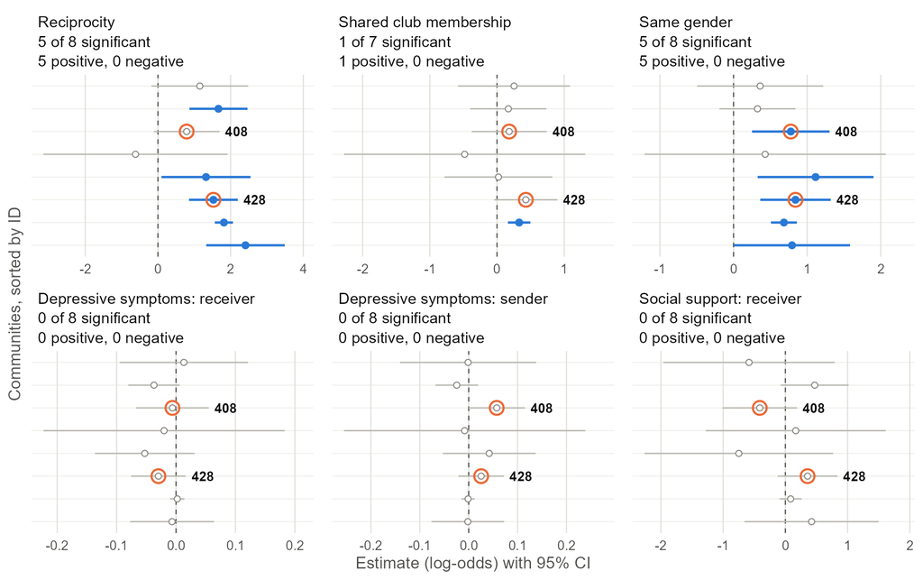

*8 communities shown in this part. Saved as `stergm_m7f4d3_dissolution_by_id_part1.pdf` / `stergm_m7f4d3_dissolution_by_id_part1.png`.*

**Part 2 of 2**

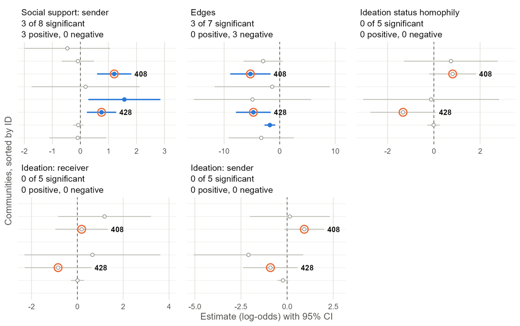

*8 communities shown in this part. Saved as `stergm_m7f4d3_dissolution_by_id_part2.pdf` / `stergm_m7f4d3_dissolution_by_id_part2.png`.*

*Across all parts: 8 communities shown of 15 fit (1 too small or too few tie changes).*

**Raw term names (to choose or order panels with `terms`)**

`Persist(1)~edges`  
`Persist(1)~nodematch.ideation_binary_w1`  
`Persist(1)~nodeicov.ideation_binary_w1`  
`Persist(1)~nodeocov.ideation_binary_w1`  
`Persist(1)~mutual`  
`Persist(1)~edgecov.shared_club`  
`Persist(1)~nodematch.gender`  
`Persist(1)~nodeicov.cesd_w1`  
`Persist(1)~nodeocov.cesd_w1`  
`Persist(1)~nodeicov.social_support_w1`  
`Persist(1)~nodeocov.social_support_w1`

# 1. Descriptive Network Analysis

Per community and wave: network size, density, average degree, clustering, reciprocity, component structure, and attribute summaries. **§** = too few cases to report (see the By Community note); suppressed communities are left out of the plots.

## Community Summary Table

Directed network descriptives by community and wave

| Community | Wave | N nodes | N arcs | Density | Avg degree | Clustering | Reciprocity | Isolates | Female (share) | Ideation W1 | CESD mean W1 | White (share) | Black (share) | Hispanic (share) | Race heterogeneity | Lost at W2 (share) |
| --- | --- | --- | --- | --- | --- | --- | --- | --- | --- | --- | --- | --- | --- | --- | --- | --- |
| 401 | 1 | 45 | 12 | 0.006 | 0.533 | 0 | 0 | 25 | 0.489 | § | 7.571 | § | § | § | 0.616 | 0.333 |
| 401 | 2 | 45 | 44 | 0.022 | 1.956 | 0.355 | 0.136 | 17 | 0.489 | § | 7.571 | § | § | § | 0.616 | 0.333 |
| 402 | 1 | 61 | 120 | 0.033 | 3.934 | 0.392 | 0.333 | § | 0.525 | § | 8.803 | § | § | § | 0.094 | § |
| 402 | 2 | 61 | 143 | 0.039 | 4.689 | 0.351 | 0.364 | § | 0.525 | § | 8.803 | § | § | § | 0.094 | § |
| 403 | 1 | 123 | 131 | 0.009 | 2.130 | 0.220 | 0.260 | 27 | 0.407 | 0.124 | 1.04e+01 | § | § | § | 0.032 | 0.350 |
| 403 | 2 | 123 | 109 | 0.007 | 1.756 | 0.137 | 0.204 | 43 | 0.407 | 0.124 | 1.04e+01 | § | § | § | 0.032 | 0.350 |
| 404 | 1 | 99 | 165 | 0.017 | 3.333 | 0.207 | 0.327 | 17 | 0.535 | § | 9.737 | § | § | § | 0.040 | 0.222 |
| 404 | 2 | 99 | 196 | 0.020 | 3.960 | 0.332 | 0.449 | 33 | 0.535 | § | 9.737 | § | § | § | 0.040 | 0.222 |
| 405 | 1 | 91 | 309 | 0.038 | 6.791 | 0.362 | 0.414 | § | 0.527 | 0.122 | 1.00e+01 | § | § | § | 0.022 | 0.198 |
| 405 | 2 | 91 | 230 | 0.028 | 5.055 | 0.345 | 0.435 | 17 | 0.527 | 0.122 | 1.00e+01 | § | § | § | 0.022 | 0.198 |
| 406 | 1 | 83 | 159 | 0.023 | 3.831 | 0.225 | 0.277 | 14 | 0.530 | 0.146 | 9.892 | § | § | § | 0.048 | 0.181 |
| 406 | 2 | 83 | 129 | 0.019 | 3.108 | 0.217 | 0.264 | 21 | 0.530 | 0.146 | 9.892 | § | § | § | 0.048 | 0.181 |
| 407 | 1 | 161 | 353 | 0.014 | 4.385 | 0.224 | 0.266 | 12 | 0.435 | 0.112 | 9.615 | § | § | § | 0.025 | 0.174 |
| 407 | 2 | 161 | 348 | 0.014 | 4.323 | 0.201 | 0.368 | 25 | 0.435 | 0.112 | 9.615 | § | § | § | 0.025 | 0.174 |
| 408 | 1 | 111 | 238 | 0.019 | 4.288 | 0.292 | 0.261 | 12 | 0.505 | 0.155 | 1.00e+01 | § | § | § | 0.053 | 0.234 |
| 408 | 2 | 111 | 281 | 0.023 | 5.063 | 0.311 | 0.306 | 28 | 0.505 | 0.155 | 1.00e+01 | § | § | § | 0.053 | 0.234 |
| 415 | 1 | 20 | 44 | 0.116 | 4.400 | 0.365 | 0.409 | § | § | § | 9.400 | § | § | § | 0 | § |
| 415 | 2 | 20 | 60 | 0.158 | 6 | 0.509 | 0.500 | § | § | § | 9.400 | § | § | § | 0 | § |
| 426 | 1 | 55 | 141 | 0.047 | 5.127 | 0.443 | 0.383 | § | 0.491 | § | 1.01e+01 | § | § | § | 0.657 | § |
| 426 | 2 | 55 | 106 | 0.036 | 3.855 | 0.378 | 0.283 | 14 | 0.491 | § | 1.01e+01 | § | § | § | 0.657 | § |
| 428 | 1 | 152 | 363 | 0.016 | 4.776 | 0.266 | 0.347 | 13 | 0.586 | 0.139 | 8.829 | § | § | § | 0.606 | 0.178 |
| 428 | 2 | 152 | 387 | 0.017 | 5.092 | 0.295 | 0.367 | 19 | 0.586 | 0.139 | 8.829 | § | § | § | 0.606 | 0.178 |
| 436 | 1 | 53 | 50 | 0.018 | 1.887 | 0.061 | 0.320 | § | 0.660 | § | 6.226 | § | § | § | 0.107 | § |
| 436 | 2 | 53 | 198 | 0.072 | 7.472 | 0.441 | 0.525 | § | 0.660 | § | 6.226 | § | § | § | 0.107 | § |
| 458 | 1 | 832 | 3359 | 0.005 | 8.075 | 0.202 | 0.386 | 27 | 0.475 | 0.162 | 1.16e+01 | § | § | § | 0.045 | 0.242 |
| 458 | 2 | 832 | 2221 | 0.003 | 5.339 | 0.206 | 0.390 | 125 | 0.475 | 0.162 | 1.16e+01 | § | § | § | 0.045 | 0.242 |
| 463 | 1 | 43 | 42 | 0.023 | 1.953 | 0.033 | 0.286 | § | 0.512 | § | 9.581 | § | § | § | 0.045 | § |
| 463 | 2 | 43 | 145 | 0.080 | 6.744 | 0.444 | 0.441 | § | 0.512 | § | 9.581 | § | § | § | 0.045 | § |
| 475 | 1 | 52 | 171 | 0.064 | 6.577 | 0.267 | 0.444 | § | 0.538 | § | 7 | § | § | § | 0.382 | § |
| 475 | 2 | 52 | 83 | 0.031 | 3.192 | 0.326 | 0.482 | § | 0.538 | § | 7 | § | § | § | 0.382 | § |
| 477 | 1 | 1721 | 3713 | 0.001 | 4.309 | 0.198 | 0.318 | 200 | 0.482 | 0.145 | 1.39e+01 | § | § | § | 0.699 | 0.322 |
| 477 | 2 | 1721 | 2040 | 0.001 | 2.368 | 0.209 | 0.282 | 591 | 0.482 | 0.145 | 1.39e+01 | § | § | § | 0.699 | 0.322 |

## Wave 1 → Wave 2 Change

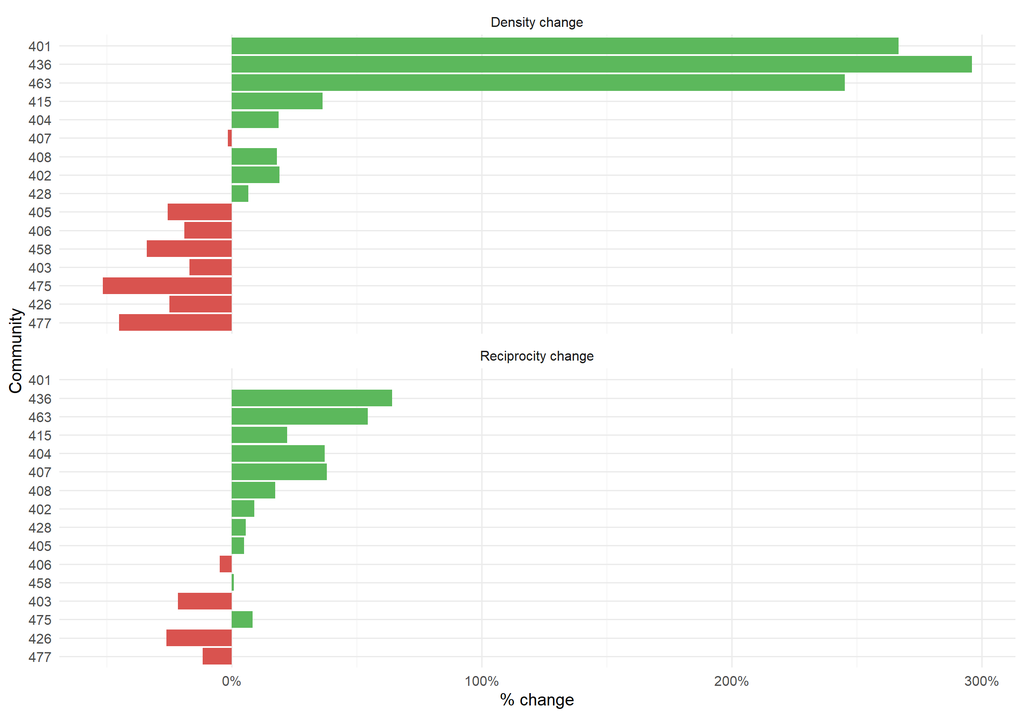

## Ideation, Exposure, CESD

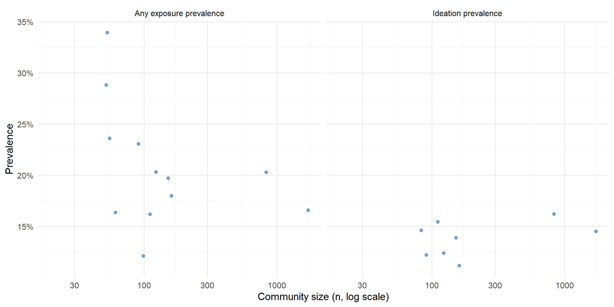

## Onset and Remission Rates

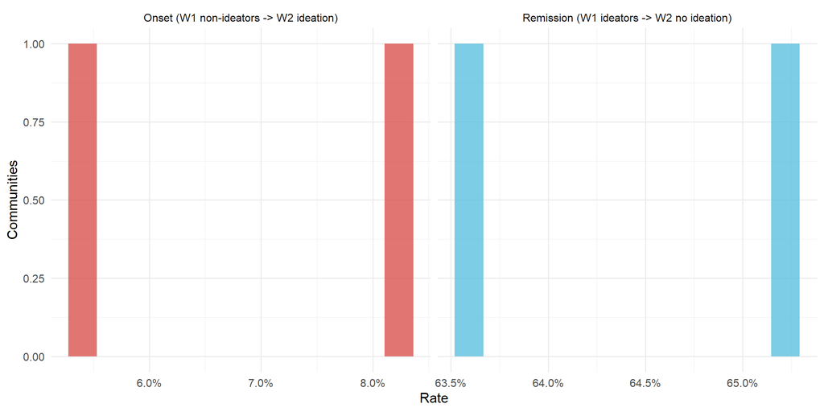

## Dyad & Triad Census

Dyad census (wave 2 counts only people observed at wave 2)

| Wave | Communities | People | Arcs | Mutual dyads | Asymmetric dyads | Share of arcs reciprocated (pooled) | Median across communities |
| --- | --- | --- | --- | --- | --- | --- | --- |
| 1 | 16 | 3,702 | 9,365 | 1,618 | 6,129 | 34.6% | 32.4% |
| 2 | 16 | 2,728 | 5,838 | 1,183 | 3,472 | 40.5% | 43.4% |

Every set of three people falls into one of 16 directed triad types. **Expected** counts come from 100 random networks per community and wave with the same numbers of mutual, asymmetric and empty pairs (the U|MAN baseline). Departures from expected therefore reflect structure *beyond* density and reciprocity, such as closure, popularity, or hierarchy. *O/E* above 1 means the type is over-represented. *Above* is the share of communities where the observed count exceeds the expected one.

Triad census pooled over communities, vs. U|MAN expectation

| Type | Description | Class | W1 observed | W1 expected | W1 O/E | W1 above | W2 O/E | W2 above |
| --- | --- | --- | --- | --- | --- | --- | --- | --- |
| 003 | empty | empty / single dyad | 938,236,617 | 938,230,465 | 1.00 | 81% | 1.00 | 100% |
| 012 | one asymmetric tie | empty / single dyad | 6,154,132 | 6,162,202 | 1.00 | 25% | 1.00 | 0% |
| 102 | one mutual tie | empty / single dyad | 1,573,959 | 1,575,141 | 1.00 | 25% | 1.00 | 31% |
| 021D | out-star: one person names both others | open | 6,468 | 5,443 | 1.19 | 81% | 1.11 | 50% |
| 021U | in-star: both name the same person | open | 7,923 | 5,441 | 1.46 | 75% | 2.24 | 94% |
| 021C | two-path: A -> B -> C | open | 8,885 | 10,886 | 0.82 | 0% | 0.86 | 0% |
| 111D | one mutual + one asymmetric tie | open | 6,055 | 6,003 | 1.01 | 50% | 1.02 | 56% |
| 111U | one mutual + one asymmetric tie | open | 5,032 | 6,010 | 0.84 | 6% | 0.78 | 12% |
| 201 | two mutual ties | open | 929 | 56 | 16.45 | 88% | 12.94 | 100% |
| 030T | transitive triple | closed, transitive | 50 | 18 | 2.75 | 31% | 1.90 | 56% |
| 030C | cyclic triple: A -> B -> C -> A | closed, cyclic | 1,166 | 1,698 | 0.69 | 19% | 0.62 | 6% |
| 120D | mutual pair + both named by third | closed, transitive | 582 | 17 | 34.85 | 81% | 19.75 | 94% |
| 120U | mutual pair + third names both | closed, transitive | 538 | 18 | 30.16 | 88% | 17.04 | 94% |
| 120C | mutual pair + two-path through third | closed, cyclic | 273 | 33 | 8.39 | 75% | 5.35 | 88% |
| 210 | two mutual ties + one asymmetric tie | closed, transitive | 640 | 20 | 31.36 | 81% | 14.63 | 94% |
| 300 | complete: all ties mutual | closed, transitive | 204 | 2 | 1.06e+02 | 62% | 39.10 | 88% |

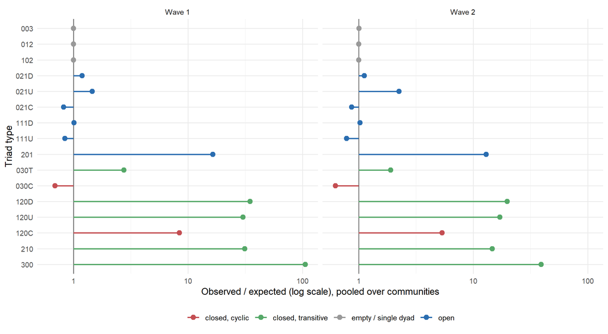

At wave 1, transitive triples (030T) occur 2.75 times as often as expected and cyclic triples (030C) 0.69 times; in-stars (021U) occur 1.46 times as often and out-stars (021D) 1.19 times. Transitive over-representation with cyclic under-representation points to transitive closure and a status ordering; in-star over-representation points to popularity differences.

**By community.** Each cell is a community’s departure from its own U|MAN expectation, standardized: (observed − expected) / SD of the simulations, capped at ±10. Red = over-represented, blue = under-represented. Communities are sorted by wave 1 size (n); wave 2 counts only people observed at wave 2.

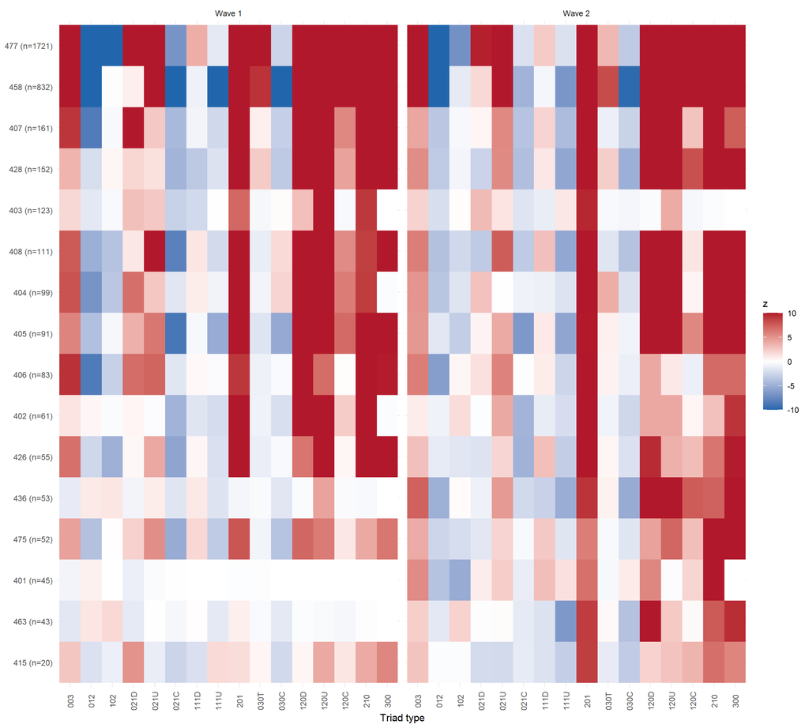